# [Chapter 12] Predicting online shopping purchase intent using CART and RF

[DSLC stages]: Analysis

In this document, you will find the PCS workflow and code for fitting the CART and RF algorithms to the online shopping data.

The following code sets up the libraries and creates cleaned and pre-processed training, validation and test data that we will use in this document.

```r
library(patchwork)
library(lubridate)
library(scales)
library(yardstick)
library(fastDummies)
library(tidyverse)
library(janitor)
library(rpart)
library(ranger)
# apply the cleaning and pre-processing functions
source("functions/prepareShoppingData.R")
# list all objects (and custom functions) that exist in our environment
ls()
```

```
 [1] "browser_levels"                      "operating_systems_levels"
 [3] "preprocessShoppingData"              "shopping_orig"
 [5] "shopping_test"                       "shopping_test_preprocessed"
 [7] "shopping_train"                      "shopping_train_preprocessed"
 [9] "shopping_train_preprocessed_nodummy" "shopping_val"
[11] "shopping_val_preprocessed"           "shopping_val_preprocessed_nodummy"
[13] "traffic_type_levels"
```

Since CART and RF can both use categorical features directly, we will primarily use the version of the shopping data with the original categorical variables (i.e., without dummy variables) `shopping_train_preprocessed_nodummy` (this is created when we run the `prepareShoppingData.R` script).

## 1 A manual CART demonstration

In this section, we will demonstrate one example of manually compute the first CART split for a small sample of 30 training sessions.

First, let’s create the sample of 30 training sessions (8 that ended with a purchase and 22 that did not).

```r
# prepare the sample data points so that they match the sample in the book
shopping_train_sample <- shopping_train[c(6529, 1278, 3304, 604,
                                          287, 6780, 1799, 2088,
                                          7188, 4690, 3892, 3347,
                                          581, 6910, 2108, 5081,
                                          1626, 2487, 3931, 2078,
                                          6192, 6527, 5814, 1534,
                                          7205, 6356, 5043, 1973,
                                          694, 2258), ] %>%
  preprocessShoppingData() |>
  select(product_related_duration, exit_rates, purchase)
```

Then, we can create a tibble with the set of potential split questions (each defined based on a variable and a threshold or value) we will consider for this small example:

```r
questions <- tribble(~variable, ~value,
                     "exit_rates", 0.010,
                     "exit_rates", 0.025,
                     "exit_rates", 0.031,
                     "product_related_duration", 8.41,
                     "product_related_duration", 3.85,
                     "product_related_duration", 15.92)
```

And define a function for computing the Gini split measure for each split option.

```r
getGini <- function(variable, value) {
  yes <- shopping_train_sample[[variable]] < value
  purchase <- parse_number(as.character(shopping_train_sample$purchase))
  gini_yes <- 1 - (sum(purchase[yes]) / sum(yes))^2 - (1 - sum(purchase[yes]) / sum(yes))^2

  gini_no <-  1 - (sum(purchase[!yes]) / sum(!yes))^2 - (1 - sum(purchase[!yes]) / sum(!yes))^2

  gini <- sum(yes) / length(yes) * gini_yes + sum(!yes) / length(yes) * gini_no


  return(tibble(split = paste0(variable, " < ", value),
                gini = round(gini, 2)))
}
```

Then we can apply this function to the set of potential split questions

```r
map2_df(questions$variable, questions$value, function(.x, .y) getGini(.x, .y))
```

```
# A tibble: 6 × 2
  split                             gini
  <chr>                            <dbl>
1 exit_rates < 0.01                 0.28
2 exit_rates < 0.025                0.37
3 exit_rates < 0.031                0.36
4 product_related_duration < 8.41   0.31
5 product_related_duration < 3.85   0.36
6 product_related_duration < 15.92  0.39
```

Fortunately, you wouldn’t have to do this manually yourself, since the `rpart()` function will do it for you (although it will consider a much broader range of split options than the set that we considered above). Below, you can see that the `rpart()` function similarly identifies `exit_rates < 0.01` as the best split option (the first split corresponds to entry 2).

```r
# set a parameter that allows to have smaller node splits than the default
prune_control = rpart.control(minsplit = 1)
shopping_example_cart <- rpart(purchase ~ product_related_duration + exit_rates,
                               shopping_train_sample,
                               control = prune_control)
shopping_example_cart
```

```
n= 30

node), split, n, loss, yval, (yprob)
      * denotes terminal node

 1) root 30 8 0 (0.2666667 0.7333333)
   2) exit_rates< 0.01003815 5 1 1 (0.8000000 0.2000000)
     4) product_related_duration< 43.59846 4 0 1 (1.0000000 0.0000000) *
     5) product_related_duration>=43.59846 1 0 0 (0.0000000 1.0000000) *
   3) exit_rates>=0.01003815 25 4 0 (0.1600000 0.8400000)
     6) product_related_duration>=7.778978 14 4 0 (0.2857143 0.7142857)
      12) product_related_duration< 16.34681 4 1 1 (0.7500000 0.2500000)
        24) exit_rates< 0.02818627 3 0 1 (1.0000000 0.0000000) *
        25) exit_rates>=0.02818627 1 0 0 (0.0000000 1.0000000) *
      13) product_related_duration>=16.34681 10 1 0 (0.1000000 0.9000000)
        26) product_related_duration< 20.39425 3 1 0 (0.3333333 0.6666667)
          52) product_related_duration>=19.89563 1 0 1 (1.0000000 0.0000000) *
          53) product_related_duration< 19.89563 2 0 0 (0.0000000 1.0000000) *
        27) product_related_duration>=20.39425 7 0 0 (0.0000000 1.0000000) *
     7) product_related_duration< 7.778978 11 0 0 (0.0000000 1.0000000) *
```

## 2 Fitting CART and RF using the entire training set

Below, we fit a CART algorithm using the entire training dataset using all of the available features.

```r
cart <- rpart(purchase ~ .,
              shopping_train_preprocessed_nodummy)
```

We can also fit a RF algorithm using the entire training dataset and all available features using the `ranger()` function from the ranger R package.

```r
set.seed(2783)
rf <- ranger(purchase ~ .,
             shopping_train_preprocessed_nodummy,
             probability = TRUE)
```

## 3 RF variable importance

To extract the variable importance from the RF fit, you actually need to specify an `importance` argument when you train the RF algorithm.

The code below retrains the RF algorithm to extract the permutation and the impurity importance measures.

```r
set.seed(2783)
rf_permutation <- ranger(purchase ~ .,
                         probability = TRUE,
                         shopping_train_preprocessed_nodummy,
                         importance = "permutation")
set.seed(2783)
rf_impurity <- ranger(purchase ~ .,
                      probability = TRUE,
                      shopping_train_preprocessed_nodummy,
                      importance = "impurity")
```

Then the importance measure values for each variable can be extracted directly from the rf objects:

```r
rf_permutation$variable.importance
```

```
          administrative  administrative_duration            informational
            0.0085549945             0.0064801981             0.0015543923
  informational_duration          product_related product_related_duration
            0.0018567936             0.0111863584             0.0107510888
            bounce_rates               exit_rates              page_values
            0.0100414615             0.0137089736             0.1037273886
             special_day                    month        operating_systems
            0.0000399639             0.0053065730             0.0001276349
                 browser                   region             traffic_type
            0.0002826462             0.0003968166             0.0007185304
                 weekend           return_visitor
            0.0001725043             0.0019421741
```

```r
rf_impurity$variable.importance
```

```
          administrative  administrative_duration            informational
               62.417165                84.974926                24.885757
  informational_duration          product_related product_related_duration
               38.680242               113.531569               137.154987
            bounce_rates               exit_rates              page_values
               96.746223               141.961850               716.575484
             special_day                    month        operating_systems
                4.776184                78.480186                23.821830
                 browser                   region             traffic_type
               25.587945                38.952670                42.265738
                 weekend           return_visitor
               11.925578                15.784567
```

And we can visualize these importance measures using a bar plot:

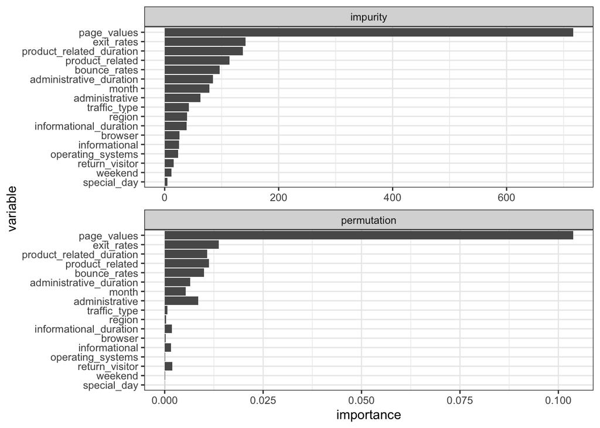

```r
# put the two importance measures in a tibble
tibble(variable = names(rf_permutation$variable.importance),
       permutation = rf_permutation$variable.importance,
       impurity = rf_impurity$variable.importance) |>
  # arrange in order of the impurity measure
  arrange(impurity) |>
  # ensure that the variable names will appear in the correct order by fixing the factor level order
  mutate(variable = fct_inorder(variable)) |>
  # convert to a longer format so we can use facet_wrap
  pivot_longer(c("permutation", "impurity"),
               names_to = "measure",
               values_to = "importance") |>
  ggplot() +
  # create bar plot
  geom_col(aes(x = variable, y = importance)) +
  # create a separate plot for each measure
  facet_wrap(~measure, ncol = 1, scales = "free") +
  # switch the x- and y-axes
  coord_flip() +
  theme_bw()
```

## 4 A PCS evaluation of the CART and RF fits

And we can then evaluate the predictability and stability of this CART fit!

### 4.1 Predictability

Let’s evaluate the CART fit using the validation set. This will involve generating validation set predictions, which we can then compare to the original logistic regression fit.

First, let’s create a version of the original LS fit

```r
lr_all <- glm(factor(purchase, levels = c(0, 1)) ~ .,
              shopping_train_preprocessed,
              family = "binomial")
```

Then we can put both our CART and LS predictions into a data frame (tibble).

```r
val_performance <-
  tibble(true = shopping_val_preprocessed$purchase,
         pred_lr_all = predict(lr_all, shopping_val_preprocessed, type = "response"),
         pred_cart = predict(cart, shopping_val_preprocessed_nodummy)[, 1],
         pred_rf = predict(rf, shopping_val_preprocessed_nodummy)$prediction[, 1])
```

And we can evaluate the performance of each fit, and format the results in the table below:

```r
val_performance |>
  pivot_longer(c("pred_lr_all", "pred_cart", "pred_rf"),
               names_to = "fit", values_to = "pred", names_prefix = "pred_") |>
  mutate(pred_binary = factor(as.numeric(pred > 0.161), levels = c(1, 0))) |>
  group_by(fit) |>
  summarise(accuracy = accuracy_vec(true, pred_binary),
            tp_rate = sens_vec(true, pred_binary),
            tn_rate = spec_vec(true, pred_binary),
            auc = roc_auc_vec(true, pred)) |>
  arrange(auc)
```

```
# A tibble: 3 × 5
  fit    accuracy tp_rate tn_rate   auc
  <chr>     <dbl>   <dbl>   <dbl> <dbl>
1 cart      0.886   0.818   0.897 0.874
2 lr_all    0.821   0.793   0.826 0.898
3 rf        0.844   0.876   0.838 0.934
```

The RF algorithm has the highest AUC, even though it has slightly lower accuracy and true negative rates than the CART algorithm for the particular 0.161 binary prediction threshold value.

Let’s look at an ROC curve for each fit below to see the overall predictive potential across all threshold values.

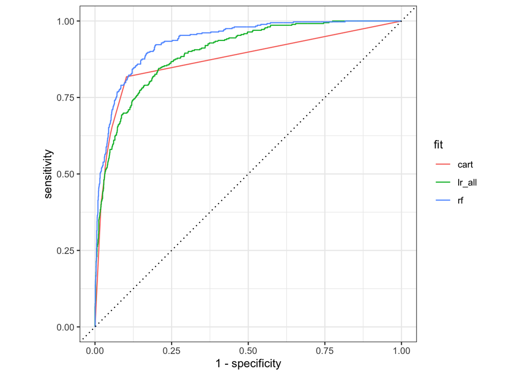

```r
val_performance |>
  pivot_longer(c("pred_lr_all", "pred_cart", "pred_rf"),
               names_to = "fit", values_to = "pred", names_prefix = "pred_") |>
  group_by(fit) |>
  roc_curve(true, pred) |>
  autoplot()
```

Since the RF ROC curve sits “above” the other two ROC curves almost everywhere, this implies that for almost every given true negative rate, there is a threshold choice for which the true positive rate will be higher for the RF algorithm than for the other two algorithms.

Lastly, we can plot density plots for the predicted purchase probability for each class:

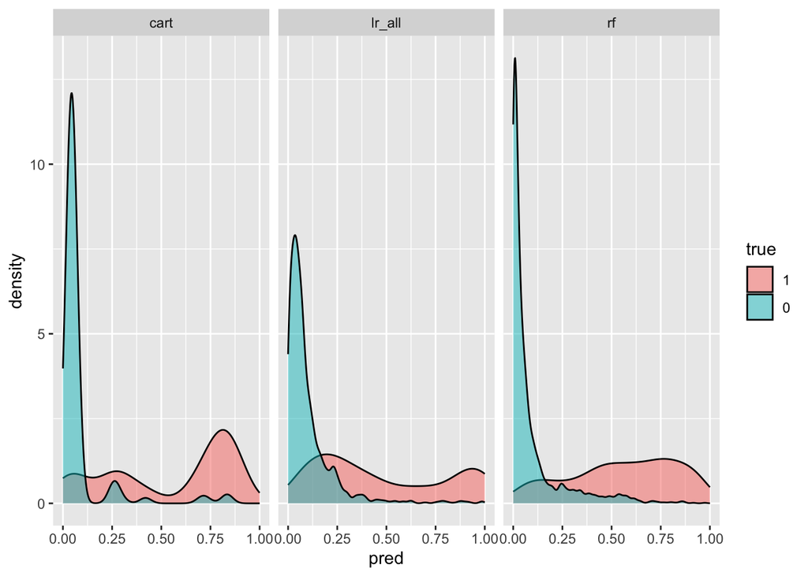

```r
val_performance |>
  pivot_longer(c("pred_lr_all", "pred_cart", "pred_rf"),
               names_to = "fit", values_to = "pred", names_prefix = "pred_") |>
  ggplot() +
  geom_density(aes(x = pred, fill = true), alpha = 0.5) +
  facet_wrap(~fit)
```

### 4.2 Stability to data perturbations

To investigate the stability of each algorithm to data perturbations (specifically, bootstrap samples), we will first create 100 perturbed versions of the training dataset and store them in a tibble as a list column:

```r
set.seed(37698)
shopping_data_perturbed <- tibble(iter = 1:100) %>%
  rowwise() %>%
  # for each row, create bootstrapped samples version of the training data
  mutate(data_train_preprocessed_perturbed = list(sample_frac(shopping_train_preprocessed, 1, replace = TRUE)))
# add a version without dummy variables for the CART and RF fits
# use the same seed
set.seed(37698)
shopping_data_perturbed <- shopping_data_perturbed |>
  mutate(data_train_preprocessed_nodummy_perturbed = list(sample_frac(shopping_train_preprocessed_nodummy, 1, replace = TRUE))) |>
  ungroup()

shopping_data_perturbed
```

```
# A tibble: 100 × 3
    iter data_train_preprocessed_perturbed data_train_preprocessed_nodummy_per…¹
   <int> <list>                            <list>
 1     1 <tibble [7,372 × 54]>             <tibble [7,372 × 18]>
 2     2 <tibble [7,372 × 54]>             <tibble [7,372 × 18]>
 3     3 <tibble [7,372 × 54]>             <tibble [7,372 × 18]>
 4     4 <tibble [7,372 × 54]>             <tibble [7,372 × 18]>
 5     5 <tibble [7,372 × 54]>             <tibble [7,372 × 18]>
 6     6 <tibble [7,372 × 54]>             <tibble [7,372 × 18]>
 7     7 <tibble [7,372 × 54]>             <tibble [7,372 × 18]>
 8     8 <tibble [7,372 × 54]>             <tibble [7,372 × 18]>
 9     9 <tibble [7,372 × 54]>             <tibble [7,372 × 18]>
10    10 <tibble [7,372 × 54]>             <tibble [7,372 × 18]>
# ℹ 90 more rows
# ℹ abbreviated name: ¹data_train_preprocessed_nodummy_perturbed
```

Then we can fit a logistic regression, CART and RF fit to each perturbed dataset (and store these in list columns too).

```r
# this code will take a while to run
shopping_data_perturbed_rf <- shopping_data_perturbed |>
  rowwise() |>
  # fit a logistic regression for each perturbed training dataset
  mutate(lr = list(glm(factor(purchase, levels = c(0, 1)) ~ .,
                       data_train_preprocessed_perturbed,
                       family = "binomial")),
         cart = list(rpart(purchase ~ .,
                           data_train_preprocessed_nodummy_perturbed)),
         rf = list(ranger(purchase ~ .,
                          data_train_preprocessed_nodummy_perturbed,
                          probability = TRUE))) |>
  ungroup()
```

Next, we can compute predictions for each validation set data point.

```r
shopping_data_perturbed_pred <- shopping_data_perturbed_rf |>
  rowwise() |>
  # create a list column of just the observed response vector
  transmute(iter,
            true_val = list(factor(shopping_val_preprocessed$purchase,
                               levels = c(1, 0))),
            pred_val_lr = list(predict(lr, shopping_val_preprocessed,
                                   type = "response")),
            pred_val_cart = list(predict(cart, shopping_val_preprocessed_nodummy)[, 1]),
            pred_val_rf = list(predict(rf, shopping_val_preprocessed_nodummy)$predictions[, 1])) |>
  ungroup() |>
  # unnest the tibble
  unnest(c(iter, true_val,
           pred_val_lr, pred_val_cart, pred_val_rf))
# Look at the object we created
print(shopping_data_perturbed_pred, width = Inf)
```

```
# A tibble: 245,600 × 5
    iter true_val pred_val_lr pred_val_cart pred_val_rf
   <int> <fct>          <dbl>         <dbl>       <dbl>
 1     1 0            0.00340        0.0460    0.0664
 2     1 0            0.00330        0.0460    0.0167
 3     1 0            0.00972        0.0460    0.0144
 4     1 0            0.00193        0.0460    0.000286
 5     1 0            0.00895        0.0460    0.0182
 6     1 0            0.00316        0.0460    0.000686
 7     1 0            0.00116        0.0460    0.0230
 8     1 0            0.00680        0.0460    0.0826
 9     1 0            0.00328        0.0460    0.0188
10     1 0            0.00440        0.0460    0.00328
# ℹ 245,590 more rows
```

And compute the validation set predictive performance for each fit.

```r
shopping_data_perturbed_performance <- shopping_data_perturbed_pred |>
  pivot_longer(c(pred_val_lr, pred_val_cart, pred_val_rf),
               names_to = "fit", values_to = "pred_val", names_prefix = "pred_val_") |>
  group_by(fit, iter) |>
  summarise(auc = roc_auc_vec(true_val, pred_val),
         tp_rate = sens_vec(true_val, factor(as.numeric(pred_val > 0.161), levels = c(1, 0))),
         tn_rate = spec_vec(true_val, factor(as.numeric(pred_val > 0.161), levels = c(1, 0))),
         accuracy = accuracy_vec(true_val, factor(as.numeric(pred_val > 0.161), levels = c(1, 0))))
```

[output not shown]

We can visualize the distributions of the perturbed performance measures using boxplots:

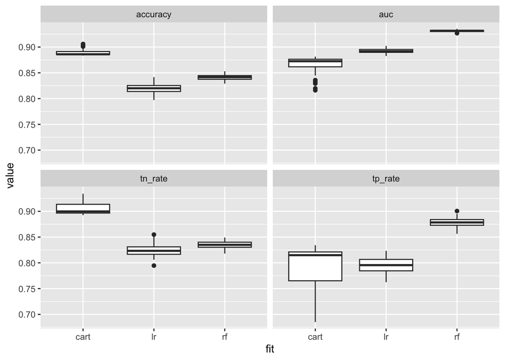

```r
shopping_data_perturbed_performance |>
  pivot_longer(c(accuracy, tp_rate, tn_rate, auc),
               names_to = "measure", values_to = "value") |>
  ggplot() +
  geom_boxplot(aes(x = fit, y = value)) +
  facet_wrap(~measure)
```

### 4.3 Stability to judgment call perturbations

The judgment calls that we will consider are:

1. Converting the numeric variables (such as `browser`, `region`, and `operating_system`) to categorical variables, or leaving them in a numeric format (just in case there is some meaningful order to the levels that we don’t know about).
2. Converting the categorical `month` variable to a numeric format (since there is a natural ordering to the months), or leaving it in a categorical format (which will be turned into one-hot encoded dummy variables during pre-processing).
3. Applying a log-transformation to the page visit and duration variables (because this makes the distributions look more symmetric, and may help improve predictive performance), or leaving them un-transformed.
4. Removing very extreme sessions (e.g., that visited over 400 product-related pages in a single session, or spent more than 12 hours on product-related pages in a single session) that may be bots, versus leaving them in the data. Note that we chose the thresholds that we use to define a potential “bot” session based on a visualization of the distributions of these variables.

Since each judgment call above has two options (TRUE or FALSE), so there are a total of $2^4 = 16$ different judgment call combinations that we will consider in this section.

The code below creates an object that contains a list column with each perturbed dataset.

First, we will create a grid of all of the judgment call options.

```r
numeric_to_cat = c(TRUE, FALSE)
month_numeric <- c(TRUE, FALSE)
log_page <- c(TRUE, FALSE)
remove_extreme <- c(TRUE, FALSE)
param_options <- expand_grid(numeric_to_cat,
                             month_numeric,
                             log_page,
                             remove_extreme)
```

Then we will create a version of the pre-processed dataset per each of the judgment call combination options. Note that unlike for the data perturbations (which were all based on the “default” pre-processed training dataset) where we could use the “default” validation dataset, we will need to explicitly create perturbed versions of the pre-processed validation data to match each perturbed version of the pre-processed training data.

```r
shopping_jc_perturbed <- param_options %>%
  rowwise() %>%
  # add training data list column
  mutate(data_train_preprocessed_perturbed =
           list(preprocessShoppingData(shopping_train,
                                    .numeric_to_cat = numeric_to_cat,
                                    .month_numeric = month_numeric,
                                    .log_page = log_page,
                                    .remove_extreme = remove_extreme)),
         .before = 1) %>%
  # create a version of the training data cat levels for matching val set to train set
  mutate(data_train_preprocessed_perturbed_nodummy =
           list(preprocessShoppingData(shopping_train,
                                    .numeric_to_cat = numeric_to_cat,
                                    .month_numeric = month_numeric,
                                    .log_page = log_page,
                                    .remove_extreme = remove_extreme,
                                    .dummy = FALSE)),
         .after = "data_train_preprocessed_perturbed") %>%
  # extract the levels to use for ensuring the validation sets match the training set
  mutate(browser_levels =
           list(levels(data_train_preprocessed_perturbed_nodummy$browser)),
         operating_systems_levels =
           list(levels(data_train_preprocessed_perturbed_nodummy$operating_systems)),
         traffic_type_levels =
           list(levels(data_train_preprocessed_perturbed_nodummy$traffic_type))) %>%
  # add validation data list column
  mutate(data_val_preprocessed_perturbed =
           list(preprocessShoppingData(shopping_val,
                                    .numeric_to_cat = numeric_to_cat,
                                    .month_numeric = month_numeric,
                                    .log_page = log_page,
                                    .remove_extreme = remove_extreme,
                                    # make sure val columns match train columns
                                    .column_selection = colnames(data_train_preprocessed_perturbed),
                                    .operating_systems_levels = operating_systems_levels,
                                    .browser_levels = browser_levels,
                                    .traffic_type_levels = traffic_type_levels)),
         data_val_preprocessed_perturbed_nodummy =
           list(preprocessShoppingData(shopping_val,
                                    .numeric_to_cat = numeric_to_cat,
                                    .month_numeric = month_numeric,
                                    .log_page = log_page,
                                    .remove_extreme = remove_extreme,
                                    # make sure val columns match train columns
                                    .column_selection = colnames(data_train_preprocessed_perturbed_nodummy),
                                    .operating_systems_levels = operating_systems_levels,
                                    .browser_levels = browser_levels,
                                    .traffic_type_levels = traffic_type_levels,
                                    .dummy = FALSE)),
         .after = "data_train_preprocessed_perturbed_nodummy")

shopping_jc_perturbed
```

```
# A tibble: 16 × 11
# Rowwise:
   data_train_preprocessed_pertu…¹ data_train_preproces…² data_val_preprocesse…³
   <list>                          <list>                 <list>
 1 <tibble [7,361 × 46]>           <tibble [7,361 × 18]>  <tibble [2,453 × 46]>
 2 <tibble [7,372 × 46]>           <tibble [7,372 × 18]>  <tibble [2,456 × 46]>
 3 <tibble [7,361 × 46]>           <tibble [7,361 × 18]>  <tibble [2,453 × 46]>
 4 <tibble [7,372 × 46]>           <tibble [7,372 × 18]>  <tibble [2,456 × 46]>
 5 <tibble [7,361 × 54]>           <tibble [7,361 × 18]>  <tibble [2,453 × 54]>
 6 <tibble [7,372 × 54]>           <tibble [7,372 × 18]>  <tibble [2,456 × 54]>
 7 <tibble [7,361 × 54]>           <tibble [7,361 × 18]>  <tibble [2,453 × 54]>
 8 <tibble [7,372 × 54]>           <tibble [7,372 × 18]>  <tibble [2,456 × 54]>
 9 <tibble [7,361 × 18]>           <tibble [7,361 × 18]>  <tibble [2,453 × 18]>
10 <tibble [7,372 × 18]>           <tibble [7,372 × 18]>  <tibble [2,456 × 18]>
11 <tibble [7,361 × 18]>           <tibble [7,361 × 18]>  <tibble [2,453 × 18]>
12 <tibble [7,372 × 18]>           <tibble [7,372 × 18]>  <tibble [2,456 × 18]>
13 <tibble [7,361 × 26]>           <tibble [7,361 × 18]>  <tibble [2,453 × 26]>
14 <tibble [7,372 × 26]>           <tibble [7,372 × 18]>  <tibble [2,456 × 26]>
15 <tibble [7,361 × 26]>           <tibble [7,361 × 18]>  <tibble [2,453 × 26]>
16 <tibble [7,372 × 26]>           <tibble [7,372 × 18]>  <tibble [2,456 × 26]>
# ℹ abbreviated names: ¹data_train_preprocessed_perturbed,
#   ²data_train_preprocessed_perturbed_nodummy,
#   ³data_val_preprocessed_perturbed
# ℹ 8 more variables: data_val_preprocessed_perturbed_nodummy <list>,
#   numeric_to_cat <lgl>, month_numeric <lgl>, log_page <lgl>,
#   remove_extreme <lgl>, browser_levels <list>,
#   operating_systems_levels <list>, traffic_type_levels <list>
```

Then we can fit a logistic regression, CART and RF fit to each perturbed dataset (and store these in list columns too).

```r
# this code will take a while to run
shopping_jc_perturbed_rf <- shopping_jc_perturbed |>
  rowwise() |>
  # fit a logistic regression for each perturbed training dataset
  mutate(lr = list(glm(factor(purchase, levels = c(0, 1)) ~ .,
                       data_train_preprocessed_perturbed,
                       family = "binomial")),
         cart = list(rpart(purchase ~ .,
                           data_train_preprocessed_perturbed_nodummy)),
         rf = list(ranger(purchase ~ .,
                          data_train_preprocessed_perturbed_nodummy,
                          probability = TRUE))) |>
  ungroup()
```

Next, we can compute predictions for each validation set data point.

```r
shopping_jc_perturbed_pred <- shopping_jc_perturbed_rf |>
  rowwise() |>
  # create a list column of just the observed response vector
  transmute(numeric_to_cat,
            month_numeric,
            log_page,
            remove_extreme,
            true_val = list(factor(data_val_preprocessed_perturbed$purchase,
                                   levels = c(1, 0))),
            pred_val_lr = list(predict(lr, data_val_preprocessed_perturbed,
                                       type = "response")),
            pred_val_cart = list(predict(cart, data_val_preprocessed_perturbed_nodummy)[, 1]),
            pred_val_rf = list(predict(rf, data_val_preprocessed_perturbed_nodummy)$predictions[, 1])) |>
  ungroup() |>
  # unnest the tibble
  unnest(c(numeric_to_cat,
           month_numeric,
           log_page,
           remove_extreme,
           true_val,
           pred_val_lr, pred_val_cart, pred_val_rf))
# Look at the object we created
print(shopping_jc_perturbed_pred, width = Inf)
```

```
# A tibble: 39,272 × 8
   numeric_to_cat month_numeric log_page remove_extreme true_val pred_val_lr
   <lgl>          <lgl>         <lgl>    <lgl>          <fct>          <dbl>
 1 TRUE           TRUE          TRUE     TRUE           0             0.0132
 2 TRUE           TRUE          TRUE     TRUE           0             0.0164
 3 TRUE           TRUE          TRUE     TRUE           0             0.0531
 4 TRUE           TRUE          TRUE     TRUE           0             0.0166
 5 TRUE           TRUE          TRUE     TRUE           0             0.0858
 6 TRUE           TRUE          TRUE     TRUE           0             0.0181
 7 TRUE           TRUE          TRUE     TRUE           0             0.0109
 8 TRUE           TRUE          TRUE     TRUE           0             0.0427
 9 TRUE           TRUE          TRUE     TRUE           0             0.0279
10 TRUE           TRUE          TRUE     TRUE           0             0.0228
   pred_val_cart pred_val_rf
           <dbl>       <dbl>
 1        0.0440     0.00238
 2        0.0440     0.00459
 3        0.0440     0.00868
 4        0.0440     0.00025
 5        0.0440     0.00999
 6        0.0440     0.0004
 7        0.0440     0
 8        0.0440     0.0239
 9        0.0440     0.0152
10        0.0440     0.0005
# ℹ 39,262 more rows
```

And compute the validation set predictive performance for each fit.

```r
shopping_jc_perturbed_performance <- shopping_jc_perturbed_pred |>
  pivot_longer(c(pred_val_lr, pred_val_cart, pred_val_rf),
               names_to = "fit", values_to = "pred_val", names_prefix = "pred_val_") |>
  group_by(fit,
           numeric_to_cat,
           month_numeric,
           log_page,
           remove_extreme) |>
  summarise(auc = roc_auc_vec(true_val, pred_val),
         tp_rate = sens_vec(true_val, factor(as.numeric(pred_val > 0.161), levels = c(1, 0))),
         tn_rate = spec_vec(true_val, factor(as.numeric(pred_val > 0.161), levels = c(1, 0))),
         accuracy = accuracy_vec(true_val, factor(as.numeric(pred_val > 0.161), levels = c(1, 0))))
```

[output not shown]

We can visualize the distributions of the perturbed performance measures using boxplots:

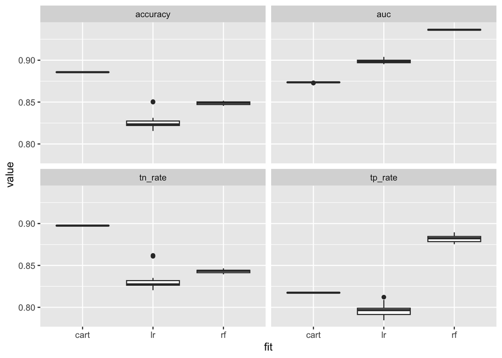

```r
shopping_jc_perturbed_performance |>
  pivot_longer(c(accuracy, tp_rate, tn_rate, auc),
               names_to = "measure", values_to = "value") |>
  ggplot() +
  geom_boxplot(aes(x = fit, y = value)) +
  facet_wrap(~measure)
```

Overall, the logistic regression is the least stable, and the RF has highest AUC and TP rate, but lower accuracy and TN rate (CART has the highest accuracy and TN rate).